# Проектирование тонкопленочных гибридных интегральных микросхем

# Вариант 29 (1)

## Исходные данные

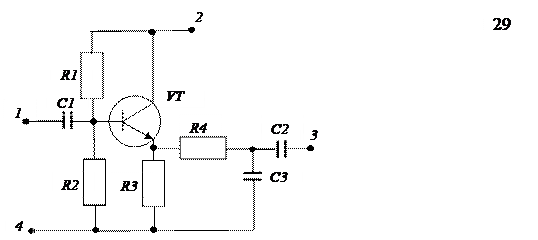

Параметры элементов:

- $R1$: 20 кОм ±10% 0,01 Вт
- $R2$: 47 кОм ±20% 0,02 Вт
- $R3$: 4.7 кОм ±10% 0,02 Вт
- $R4$: 2 кОм ±10% 0,02 Вт
- $C1$: 1000 пФ
- $C2$: 330 пФ
- $C3$: 1000 пФ

## Расчет параметров ГИС

### 1. Расчет размеров пленочных резисторов

Опеределим оптимальное удельное поверхностное сопротивление:

$$\rho_□ = \sqrt{\frac{\sum R}{\sum
R^{-1}}} = 9695 \text{Ом} \approx 10000 \text{Ом}$$

Материал с ближайшим значением $\rho_□$, удовлетворяющий необходимому диапазону значений сопротивления — *Кермет К-50С* с удельной мощностью рассеивания $W_0 = 2$ Вт/см^2.

Определим ширину резисторов $b_w$, обеспечивающую необходимую мощность рассеивания:

$$b_w = \sqrt{\frac{\rho_□ \cdot W}{R
\cdot W_0}}$$

(Значения округляются в большую сторону до шага сетки $H = 0.1$ мм)

Определим ширину резисторов $b$ с поправкой на точность изготовления:

$$b_1=0.6\text{мм},b_2=0.5\text{мм},b_3=1.5\text{мм},b_4=2.3\text{мм}$$

Определим длины резисторов:

$$l = \frac{R}{\rho_□}\cdot b = k_ф \cdot
b$$

(Значения округляются до ближайшего, кратного шагу сетки $H = 0.1$ мм)

$$k_{ф1}=2,k_{ф2}=4.7,k_{ф3}=0.47,k_{ф4}=0.2$$
$$l_1=1.2\text{мм},l_2=2.35 \approx
2.4\text{мм},l_3=0.705 \approx 0.7\text{мм},l_4=0.46 \approx
0.5\text{мм}$$

Оценим погрешность, вызванную округлением:

$$\Delta R' = \frac{\|R -
R'\|}{R}\cdot 100\%,\ R' = \frac{l\cdot\rho_□}{b}$$

$$\Delta R'_1=0\%,\Delta
R'_2=2\%,\Delta R'_3=1\%,\Delta R'_4=9\%$$

Для каждого из резисторов погрешность удовлетворяет условию $\Delta R' \leq \Delta R$.

### 2. Расчет размеров пленочных конденсаторов

Расчет сводится к определению активной площади конденсаторов:

$$S = \frac{C}{C_0}$$

Для минимизации размеров найдем $C_{min}$, взяв $S_0 = 0.25$ мм^2 (минимально возможную площадь):

$$C_{min} =
min(\frac{C_i}{S_0})$$

Наиболее подходящим материалом диэлектрика является *моноокись германия*, поскольку оно обладает высокой удельной емкостью $C_0 = 15 * 10^3$ пФ/см^2.

### 3. Конструирование пленочных межсоединений и контактных площадок

Контактные площадки изготавливаются из алюминия А99.

### 4. Проектирование защитного слоя

Защитный слой может быть изготовлен из любой диэлектрической пленки, за исключением пятиокиси тантала.

## Итоговая схема

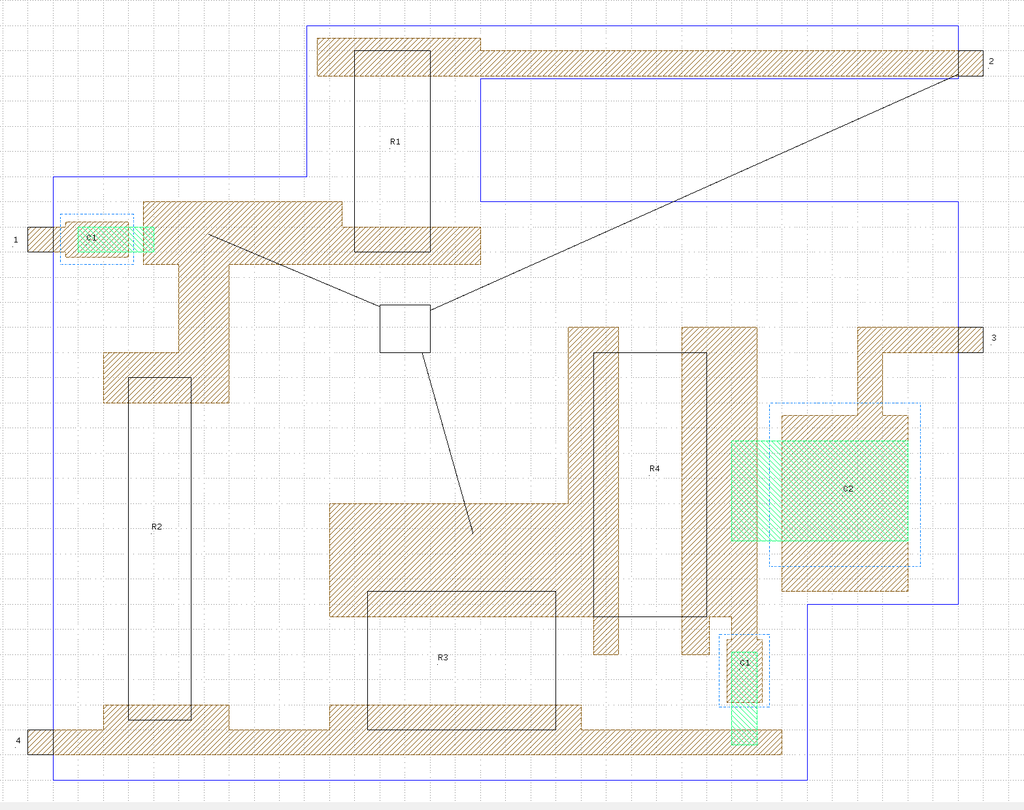

Рисунок 2. Итоговая схема